# CSCI E-63C Week 12 Problem Set

# Preface

This week problem set will explore behavior of support vector classifiers and SVMs (following the distinction made in ISLR) on WiFi localization dataset from UCI ML archive. We worked with it on multiple occasions before (most recently two weeks ago evaluating performance of logistic regression, discriminant analysis and KNN on it). As two weeks ago we are going to convert the four-levels outcome in the data file to the binary one indicating localization at the third location:

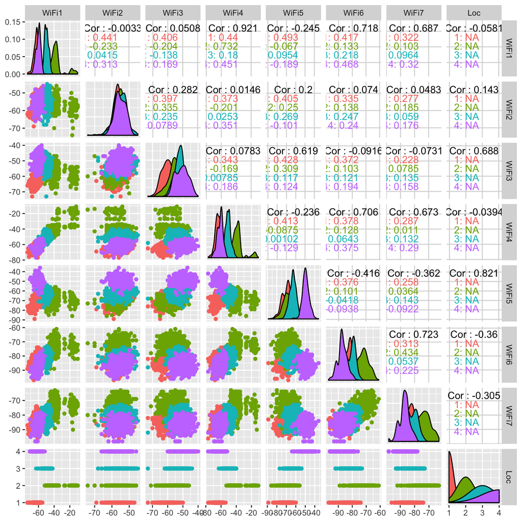

```r
wifiLocDat <- read.table("wifi_localization.txt",sep="\t")
colnames(wifiLocDat) <- c(paste0("WiFi",1:7),"Loc")
ggpairs(wifiLocDat,aes(colour=factor(Loc)))
```

```r
wifiLocDat[,"Loc3"] <- factor(wifiLocDat[,"Loc"]==3)
wifiLocDat <- wifiLocDat[,colnames(wifiLocDat)!="Loc"]
dim(wifiLocDat)
```

```
## [1] 2000    8
```

```r
summary(wifiLocDat)
```

```
##      WiFi1            WiFi2            WiFi3            WiFi4
##  Min.   :-74.00   Min.   :-74.00   Min.   :-73.00   Min.   :-77.00
##  1st Qu.:-61.00   1st Qu.:-58.00   1st Qu.:-58.00   1st Qu.:-63.00
##  Median :-55.00   Median :-56.00   Median :-55.00   Median :-56.00
##  Mean   :-52.33   Mean   :-55.62   Mean   :-54.96   Mean   :-53.57
##  3rd Qu.:-46.00   3rd Qu.:-53.00   3rd Qu.:-51.00   3rd Qu.:-46.00
##  Max.   :-10.00   Max.   :-45.00   Max.   :-40.00   Max.   :-11.00
##      WiFi5            WiFi6            WiFi7           Loc3
##  Min.   :-89.00   Min.   :-97.00   Min.   :-98.00   FALSE:1500
##  1st Qu.:-69.00   1st Qu.:-86.00   1st Qu.:-87.00   TRUE : 500
##  Median :-64.00   Median :-82.00   Median :-83.00
##  Mean   :-62.64   Mean   :-80.98   Mean   :-81.73
##  3rd Qu.:-56.00   3rd Qu.:-77.00   3rd Qu.:-78.00
##  Max.   :-36.00   Max.   :-61.00   Max.   :-63.00
```

```r
head(wifiLocDat)
```

```
##   WiFi1 WiFi2 WiFi3 WiFi4 WiFi5 WiFi6 WiFi7  Loc3
## 1   -64   -56   -61   -66   -71   -82   -81 FALSE
## 2   -68   -57   -61   -65   -71   -85   -85 FALSE
## 3   -63   -60   -60   -67   -76   -85   -84 FALSE
## 4   -61   -60   -68   -62   -77   -90   -80 FALSE
## 5   -63   -65   -60   -63   -77   -81   -87 FALSE
## 6   -64   -55   -63   -66   -76   -88   -83 FALSE
```

> Here we will use SVM implementation available in library `e1071` to fit classifiers with linear and radial (polynomial for extra points) kernels and compare their relative performance as well as to that of random forest and KNN.